# Self-Driving Car Engineer Nanodegree

### Output Top 5 Softmax Probabilities For Each Image Found on the Web

[figure not shown]

```
Actual: Class 17, No entry
Prediction: 17, No entry,
    softmax value = 0.9999998807907104
Prediction: 40, Roundabout mandatory,
    softmax value = 8.768260784108861e-08
Prediction: 34, Turn left ahead,
    softmax value = 5.576746286983791e-10
Prediction: 14, Stop,
    softmax value = 1.2246374747615363e-10
Prediction: 0, Speed limit (20km/h),
    softmax value = 7.363516914271617e-12
----------------------------------------------------------------------------
```

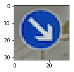

```
Actual: Class 38, Keep right
Prediction: 38, Keep right,
    softmax value = 1.0
Prediction: 14, Stop,
    softmax value = 1.9819158792420966e-13
Prediction: 34, Turn left ahead,
    softmax value = 1.1160605724097258e-13
Prediction: 25, Road work,
    softmax value = 1.6260459301188808e-14
Prediction: 10, No passing for vehicles over 3.5 metric tons,
    softmax value = 1.2219011092598593e-17
----------------------------------------------------------------------------
```

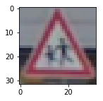

```
Actual: Class 28, Children crossing
Prediction: 28, Children crossing,
    softmax value = 0.9995964169502258
Prediction: 35, Ahead only,
    softmax value = 0.00028798929997719824
Prediction: 29, Bicycles crossing,
    softmax value = 6.172269058879465e-05
Prediction: 26, Traffic signals,
    softmax value = 4.5448825403582305e-05
Prediction: 20, Dangerous curve to the right,
    softmax value = 5.712845904781716e-06
----------------------------------------------------------------------------
```

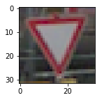

```
Actual: Class 13, Yield
Prediction: 13, Yield,
    softmax value = 0.9999997615814209
Prediction: 15, No vehicles,
    softmax value = 2.286993492361944e-07
Prediction: 12, Priority road,
    softmax value = 5.018903959097543e-09
Prediction: 9, No passing,
    softmax value = 1.1437415459170097e-09
Prediction: 38, Keep right,
    softmax value = 8.867986345251211e-10
----------------------------------------------------------------------------
```

[figure not shown]

```
Actual: Class 14, Stop
Prediction: 14, Stop,
    softmax value = 0.9806466102600098
Prediction: 17, No entry,
    softmax value = 0.012354617938399315
Prediction: 12, Priority road,
    softmax value = 0.002766852965578437
Prediction: 33, Turn right ahead,
    softmax value = 0.0018178269965574145
Prediction: 38, Keep right,
    softmax value = 0.0016013233689591289
----------------------------------------------------------------------------
```

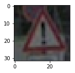

```
Actual: Class 18, General caution
Prediction: 18, General caution,
    softmax value = 0.9998679161071777
Prediction: 26, Traffic signals,
    softmax value = 0.00013060460332781076
Prediction: 27, Pedestrians,
    softmax value = 1.428830955774174e-06
Prediction: 28, Children crossing,
    softmax value = 2.1339237932238575e-08
Prediction: 38, Keep right,
    softmax value = 2.909614105206515e-09
----------------------------------------------------------------------------
```

```python
### Print out the top five softmax probabilities for the predictions on the German traffic sign images found on the web.
### Feel free to use as many code cells as needed.

with tf.Session() as sess:
    #saver.restore(sess, tf.train.latest_checkpoint('.'))
    saver.restore(sess,'./lenetbetter2')

    softmax = tf.nn.softmax(logits)

    k = 5
    top_k = tf.nn.top_k(softmax, k=k)

    softmaxes = sess.run(softmax, feed_dict={x: X_test_2_normed, keep_prob: 1.0})

    #print(softmaxes)

    top_k_array = sess.run(top_k, feed_dict={x: X_test_2_normed, keep_prob: 1.0})

    #print(top_k_array)


    for img_idx in range(len(y_test_2)):
        image = X_test_2[img_idx,:,:,:]/255
        fig = plt.figure(figsize=(2,2))
        plt.imshow(image)
        display(fig)
        plt.close()
        print("Actual: Class {}, {}".format(y_test_2[img_idx],sign_names[y_test_2[img_idx]]))
        for idx in range(k):
            pred = top_k_array.indices[img_idx,idx]
            val = top_k_array.values[img_idx,idx]
            #print("Predicted Class {} with softmax value {}".format(pred,val))
            print("Prediction: {}, {},\n    softmax value = {}".format(
                pred,
                sign_names[pred],
                val))
        print("----------------------------------------------------------------------------\n")
```

### Project Writeup

Once you have completed the code implementation, document your results in a project writeup using this [template](https://github.com/udacity/CarND-Traffic-Sign-Classifier-Project/blob/master/writeup_template.md) as a guide. The writeup can be in a markdown or pdf file.

## Step 4 (Optional): Visualize the Neural Network's State with Test Images

This Section is not required to complete but acts as an additional excersise for understaning the output of a neural network's weights. While neural networks can be a great learning device they are often referred to as a black box. We can understand what the weights of a neural network look like better by plotting their feature maps. After successfully training your neural network you can see what it's feature maps look like by plotting the output of the network's weight layers in response to a test stimuli image. From these plotted feature maps, it's possible to see what characteristics of an image the network finds interesting. For a sign, maybe the inner network feature maps react with high activation to the sign's boundary outline or to the contrast in the sign's painted symbol.

Provided for you below is the function code that allows you to get the visualization output of any tensorflow weight layer you want. The inputs to the function should be a stimuli image, one used during training or a new one you provided, and then the tensorflow variable name that represents the layer's state during the training process, for instance if you wanted to see what the LeNet lab's feature maps looked like for it's second convolutional layer you could enter conv2 as the tf_activation variable.

For an example of what feature map outputs look like, check out NVIDIA's results in their paper [End-to-End Deep Learning for Self-Driving Cars](https://devblogs.nvidia.com/parallelforall/deep-learning-self-driving-cars/) in the section Visualization of internal CNN State. NVIDIA was able to show that their network's inner weights had high activations to road boundary lines by comparing feature maps from an image with a clear path to one without. Try experimenting with a similar test to show that your trained network's weights are looking for interesting features, whether it's looking at differences in feature maps from images with or without a sign, or even what feature maps look like in a trained network vs a completely untrained one on the same sign image.

[figure not shown]

Your output should look something like this (above)

```python
### Visualize your network's feature maps here.
### Feel free to use as many code cells as needed.

# image_input: the test image being fed into the network to produce the feature maps
# tf_activation: should be a tf variable name used during your training procedure that represents the calculated state of a specific weight layer
# activation_min/max: can be used to view the activation contrast in more detail, by default matplot sets min and max to the actual min and max values of the output
# plt_num: used to plot out multiple different weight feature map sets on the same block, just extend the plt number for each new feature map entry

def outputFeatureMap(image_input, tf_activation, activation_min=-1, activation_max=-1 ,plt_num=1):
    # Here make sure to preprocess your image_input in a way your network expects
    # with size, normalization, ect if needed
    # image_input =
    # Note: x should be the same name as your network's tensorflow data placeholder variable
    # If you get an error tf_activation is not defined it may be having trouble accessing the variable from inside a function
    activation = tf_activation.eval(session=sess,feed_dict={x : image_input})
    featuremaps = activation.shape[3]
    plt.figure(plt_num, figsize=(15,15))
    for featuremap in range(featuremaps):
        plt.subplot(6,8, featuremap+1) # sets the number of feature maps to show on each row and column
        plt.title('FeatureMap ' + str(featuremap)) # displays the feature map number
        if activation_min != -1 & activation_max != -1:
            plt.imshow(activation[0,:,:, featuremap], interpolation="nearest", vmin =activation_min, vmax=activation_max, cmap="gray")
        elif activation_max != -1:
            plt.imshow(activation[0,:,:, featuremap], interpolation="nearest", vmax=activation_max, cmap="gray")
        elif activation_min !=-1:
            plt.imshow(activation[0,:,:, featuremap], interpolation="nearest", vmin=activation_min, cmap="gray")
        else:
            plt.imshow(activation[0,:,:, featuremap], interpolation="nearest", cmap="gray")
```